# Women’s Political Empowerment Index, 2025

Exercise with maps

Author

Affiliation

Christophe Bontemps (SIAP)

```r
library(sf)
library(dplyr)
library(readr)
library(ggplot2)
library(rnaturalearth)
library(classInt)

# Number of classes for each map
n_equal <- 5
n_jenks <- 5

# Equal Earth projection (equal-area, suited to choropleths)
crs_map <- "+proj=eqearth +lon_0=0"
```

## Data and boundaries

Data: *Women’s Political Empowerment Index* (0 = lowest, 1 = highest), [Our World in Data, 2025](https://ourworldindata.org/grapher/women-political-empowerment-index?tab=table&time=2025). Boundaries: Natural Earth via `rnaturalearth`. Countries without data are shown in grey.

### About the index

**Women’s political empowerment** is defined as a process of increasing capacity for women, leading to greater choice, agency, and participation in societal decision-making. It is understood to incorporate three equally-weighted dimensions: fundamental civil liberties, women’s open discussion of political issues and participation in civil society organizations, and the descriptive representation of women in formal political positions.

The index is made up of three sub-indices: women’s civil liberties, women’s civil society participation, and women’s political participation (seehttps://ourworldindata.org/women-rights.).

```r
dat <- read_csv("Data/OurWinData2026-women-political-empowerment-index.csv",
                show_col_types = FALSE) |>
  rename(index = `Women's Political Empowerment Index`,
         region = `World region according to OWID`)

world_ll <- ne_countries(scale = "medium", returnclass = "sf") |>
  filter(adm0_a3 != "ATA") |>                       # Antarctica is not a country
  mutate(Code = case_when(
    adm0_a3 == "KOS"                ~ "OWID_KOS",    # Kosovo
    adm0_a3 %in% c("IOA", "ATC")    ~ NA_character_, # Australian external territories
    TRUE                            ~ iso_a3_eh      # fixes France / Norway
  ),
  area_m2 = as.numeric(st_area(geometry))) |>
  left_join(dat, by = "Code")

world <- st_transform(world_ll, crs_map)

# Sanity check: every country in the data set is on the map
stopifnot(all(dat$Code %in% world$Code))
cat(nrow(dat), "countries with data;",
    sum(is.na(world$index)), "map units without data (grey)\n")
```

```
175 countries with data; 66 map units without data (grey)
```

```r
# Build class labels from break values; classes use the exact breaks
classify <- function(x, breaks, digits = 2) {
  lab <- paste0(formatC(head(breaks, -1), format = "f", digits = digits), " to ",
                formatC(tail(breaks, -1), format = "f", digits = digits))
  factor(cut(x, breaks, include.lowest = TRUE, labels = lab), levels = lab)
}

# Small countries are invisible at world scale: add a marker so all are represented
small <- world |>
  filter(!is.na(index), area_m2 < 2.5e10) |>   # < 25,000 km²
  st_point_on_surface()

map_theme <- theme_void(base_size = 12) +
  theme(plot.background  = element_rect(fill = "white", colour = NA),
        panel.background = element_rect(fill = "white", colour = NA),   # white oceans
        legend.position  = "bottom",
        legend.title     = element_text(face = "bold"),
        plot.title       = element_text(face = "bold", size = 15),
        plot.caption     = element_text(colour = "grey35", hjust = 0))

make_map <- function(fills, title, subtitle, legend_title,
                     w = world, sm = small, context = NULL, window = NULL,
                     dot_size = 1.6, caption_extra = "") {
  ggplot() +
    {if (!is.null(context))
      geom_sf(data = context, fill = "grey96", colour = "white", linewidth = 0.15)} +
    geom_sf(data = w, aes(fill = cls), colour = "white", linewidth = 0.15) +
    geom_sf(data = sm, aes(fill = cls), shape = 21, size = dot_size,
            colour = "grey25", stroke = 0.25, show.legend = FALSE) +
    scale_fill_manual(values = fills, na.value = "grey80", drop = FALSE,
                      name = legend_title, na.translate = TRUE,
                      labels = function(x) ifelse(is.na(x), "No data", x),
                      guide = guide_legend(nrow = 1, title.position = "top",
                                           override.aes = list(colour = "grey40"))) +
    labs(title = title, subtitle = subtitle,
         caption = paste0("Source: Our World in Data, Women's Political Empowerment Index, 2025. Boundaries: Natural Earth.",
                          caption_extra)) +
    {if (!is.null(window))
      coord_sf(xlim = window$x, ylim = window$y, expand = FALSE)} +
    map_theme
}
```

## Map 1 — Equal intervals, single purple hue

Classes of equal width across the observed range; lightness of one hue encodes the level.

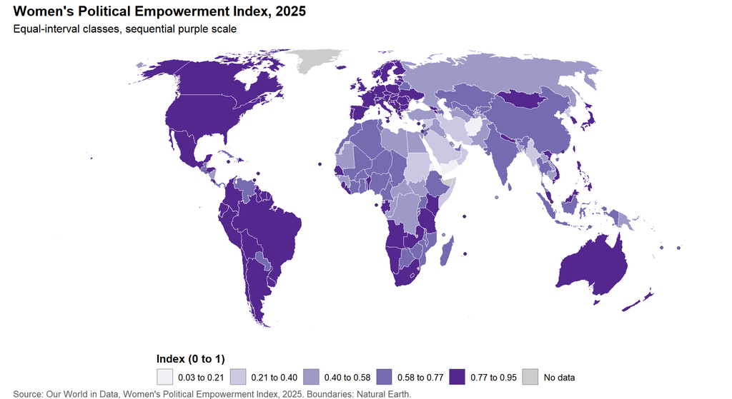

```r
br_equal <- seq(min(dat$index), max(dat$index), length.out = n_equal + 1)
world$cls <- classify(world$index, br_equal)
small$cls <- classify(small$index, br_equal)

purples <- c("#f2f0f7", "#cbc9e2", "#9e9ac8", "#756bb1", "#54278f")

make_map(purples,
         "Women's Political Empowerment Index, 2025",
         "Equal-interval classes, sequential purple scale",
         "Index (0 to 1)")
```

## Map 2 — Jenks natural breaks, a different hue for each level

Jenks breaks minimise within-class variance, so class limits follow gaps in the data. A diverging, colour-blind-safe palette gives each level its own hue (red → yellow → blue).

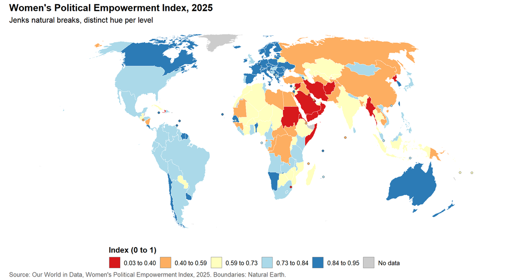

```r
br_jenks <- classIntervals(dat$index, n = n_jenks, style = "jenks")$brks
world$cls <- classify(world$index, br_jenks)
small$cls <- classify(small$index, br_jenks)

hues <- c("#d7191c", "#fdae61", "#ffffbf", "#abd9e9", "#2c7bb6")   # RdYlBu, 5 classes

make_map(hues,
         "Women's Political Empowerment Index, 2025",
         "Jenks natural breaks, distinct hue per level",
         "Index (0 to 1)")
```

### With bad selection of hues

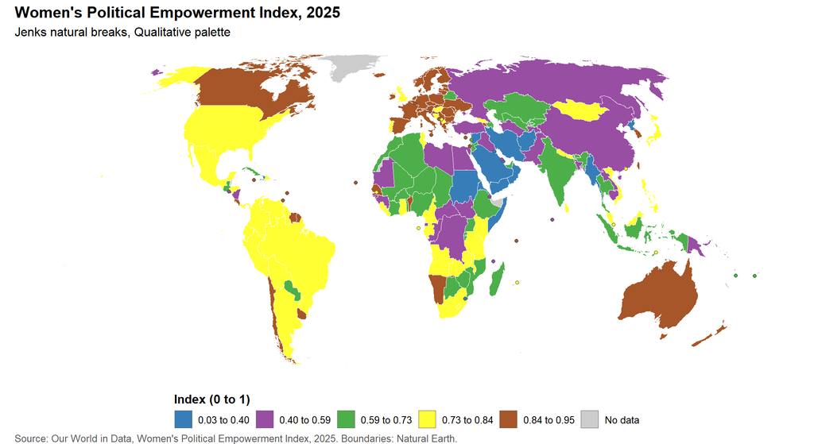

```r
br_jenks <- classIntervals(dat$index, n = n_jenks, style = "jenks")$brks
world$cls <- classify(world$index, br_jenks)
small$cls <- classify(small$index, br_jenks)

Qhues <- c('#377eb8', '#984ea3', '#4daf4a',"#ffff33", "#a65628")  #  5 classes

make_map(Qhues,
         "Women's Political Empowerment Index, 2025",
         "Jenks natural breaks, Qualitative palette",
         "Index (0 to 1)")
```

## Asia-Pacific focus

Same two maps, zoomed to the Asia-Pacific region (UN ESCAP member States in Asia and the Pacific). **Class breaks are the global ones** from Maps 1 and 2, so colours mean the same thing as above. Countries outside the region are shown in light grey for context; “No data” stays darker grey. Map 3 uses a single **green** hue; Map 4 keeps a distinct hue per level.

```r
# ESCAP regional members (geographic Asia-Pacific; excludes FRA, GBR, NLD, USA)
ap_codes <- c("AFG","ARM","AUS","AZE","BGD","BTN","BRN","KHM","CHN","FJI","GEO","IND",
              "IDN","IRN","JPN","KAZ","KIR","PRK","KOR","KGZ","LAO","MYS","MDV","MHL",
              "FSM","MNG","MMR","NRU","NPL","NZL","PAK","PLW","PNG","PHL","RUS","WSM",
              "SGP","SLB","LKA","TJK","THA","TLS","TON","TUR","TKM","TUV","UZB","VUT","VNM")

crs_ap <- "+proj=eqearth +lon_0=120"            # centred on the region; Pacific stays in one piece

# Crop to the region's longitude window (25E to 145W) on both sides of the antimeridian
suppressMessages(sf_use_s2(FALSE))
box <- function(x0, x1) st_as_sfc(st_bbox(c(xmin = x0, xmax = x1, ymin = -50, ymax = 80), crs = 4326))
world_ap <- bind_rows(suppressWarnings(st_crop(world_ll, box(25, 180))),
                      suppressWarnings(st_crop(world_ll, box(-180, -145)))) |>
  mutate(in_ap = Code %in% ap_codes) |>
  st_transform(crs_ap)
suppressMessages(sf_use_s2(TRUE))

ap_data <- world_ap |> filter(in_ap)
ap_ctx  <- world_ap |> filter(!in_ap) |> st_geometry() |> st_sf()

ap_data$cls_equal <- classify(ap_data$index, br_equal)
ap_data$cls_jenks <- classify(ap_data$index, br_jenks)

ap_small <- ap_data |> filter(area_m2 < 2.5e10) |>   # also no-data micro-states (shown grey)
  st_point_on_surface() |> suppressWarnings()

# Map window in projected coordinates
corner <- st_sfc(st_point(c(25, 0)), st_point(c(-145, 0)),
                 st_point(c(120, -48)), st_point(c(120, 78)), crs = 4326) |>
  st_transform(crs_ap) |> st_coordinates()
ap_window <- list(x = sort(corner[1:2, "X"]), y = sort(corner[3:4, "Y"]))

# Which ESCAP members have no index value?
missing_ap <- setdiff(ap_codes, dat$Code)
cat("ESCAP members without data (grey):", ifelse(length(missing_ap), paste(missing_ap, collapse = ", "), "none"), "\n")
```

```
ESCAP members without data (grey): BRN, KIR, MHL, FSM, NRU, PLW, WSM, TON, TUV
```

### Map 3 — Equal intervals, single green hue

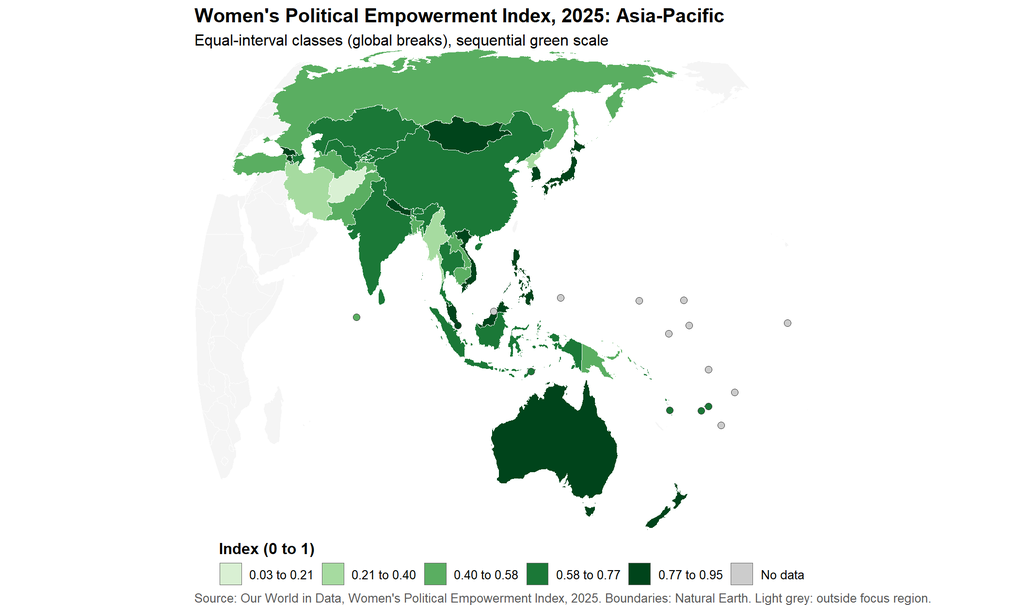

```r
greens <- c("#d9f0d3", "#a6dba0", "#5aae61", "#1b7837", "#00441b")
w3 <- ap_data |> mutate(cls = cls_equal)
s3 <- ap_small |> mutate(cls = cls_equal)

make_map(greens,
         "Women's Political Empowerment Index, 2025: Asia-Pacific",
         "Equal-interval classes (global breaks), sequential green scale",
         "Index (0 to 1)",
         w = w3, sm = s3, context = ap_ctx, window = ap_window, dot_size = 2.4,
         caption_extra = " Light grey: outside focus region.")
```

### Map 4 — Jenks natural breaks, a different hue for each level

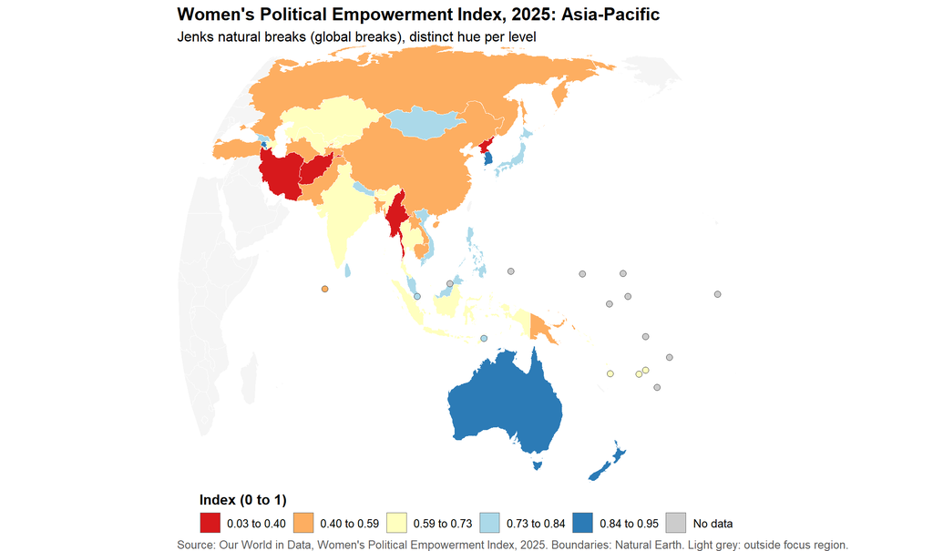

```r
w4 <- ap_data |> mutate(cls = cls_jenks)
s4 <- ap_small |> mutate(cls = cls_jenks)

make_map(hues,
         "Women's Political Empowerment Index, 2025: Asia-Pacific",
         "Jenks natural breaks (global breaks), distinct hue per level",
         "Index (0 to 1)",
         w = w4, sm = s4, context = ap_ctx, window = ap_window, dot_size = 2.4,
         caption_extra = " Light grey: outside focus region.")
```

## Proportional symbol maps

Instead of colouring countries, each country gets a symbol placed inside it whose size encodes the index value (0 to 1). Countries are drawn light grey; countries **without data** are darker grey and carry no symbol. Symbols sit at an interior point of each country, so overlaps are expected in crowded areas (Europe, Caribbean, Pacific).

```r
# Interior point of each country with data; draw large symbols first so small ones stay visible
pts <- world |>
  filter(!is.na(index)) |>
  st_point_on_surface() |>
  suppressWarnings()
xy  <- st_coordinates(pts)
pts <- pts |> mutate(x = xy[, "X"], y = xy[, "Y"]) |> arrange(desc(index))

sym_col <- "#54278f"   # same purple as Map 1

# Base map: light grey with data, darker grey without
prop_base <- function() {
  ggplot() +
    geom_sf(data = world, aes(fill = is.na(index)), colour = "white", linewidth = 0.15,
            show.legend = FALSE) +
    scale_fill_manual(values = c(`FALSE` = "grey92", `TRUE` = "grey78"))
}

prop_labs <- labs(title = "Women's Political Empowerment Index, 2025",
                  caption = "Source: Our World in Data, Women's Political Empowerment Index, 2025. Boundaries: Natural Earth. Dark grey: no data.")

size_scale <- scale_size_area(max_size = 8, limits = c(0, 1),
                              breaks = c(0.25, 0.5, 0.75, 1), name = "Index (0 to 1)")
size_guide <- guides(size = guide_legend(nrow = 1, title.position = "top",
                                         override.aes = list(alpha = 1)))
```

### Map 5 — Proportional circles

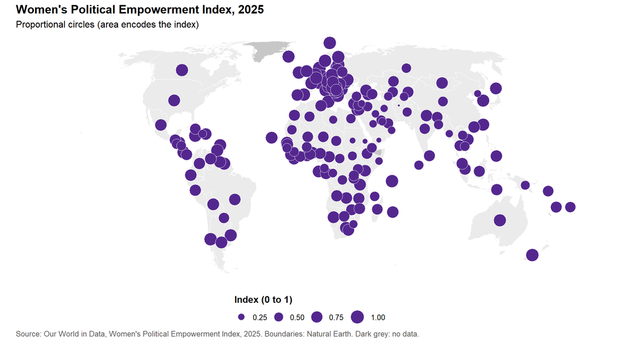

```r
prop_base() +
  geom_point(data = pts, aes(x = x, y = y, size = index),
             shape = 21, fill = sym_col, colour = "white", stroke = 0.3) +
  size_scale + size_guide +
  prop_labs + labs(subtitle = "Proportional circles (area encodes the index)") +
  map_theme
```

### Map 6 — Proportional circles with transparency

Semi-transparent fill with a solid outline keeps overlapping circles readable.

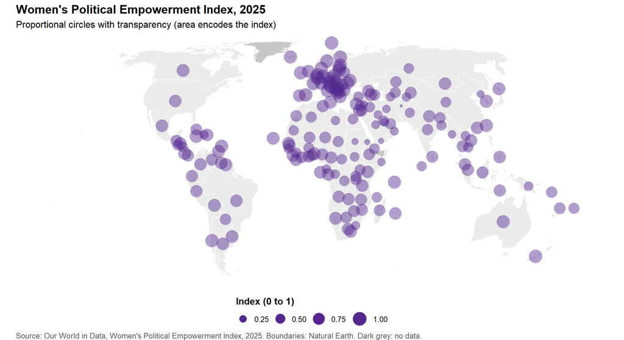

```r
prop_base() +
  geom_point(data = pts, aes(x = x, y = y, size = index),
             shape = 21, fill = sym_col, alpha = 0.45, colour = sym_col, stroke = 0.5) +
  size_scale + size_guide +
  prop_labs + labs(subtitle = "Proportional circles with transparency (area encodes the index)") +
  map_theme
```

### Map 7 — Proportional bars

Bar height is proportional to the index; the reference bars in the lower left show the scale.

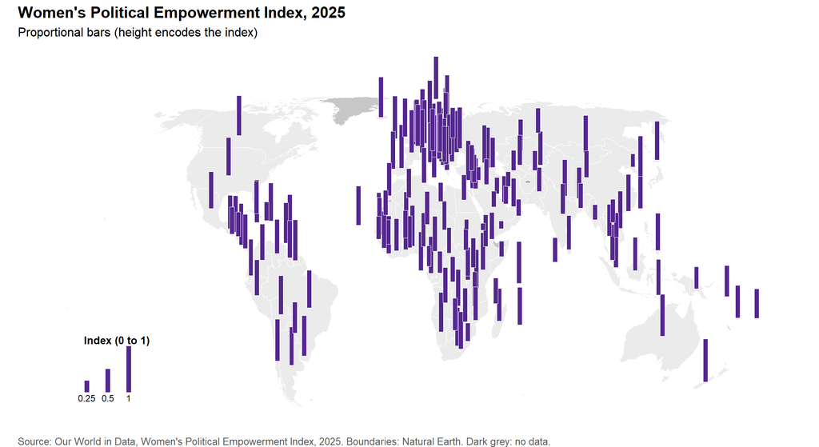

```r
bar_h <- 2.2e6   # map units (metres) for an index of 1
bar_w <- 2.2e5

bb  <- st_bbox(world)
leg <- tibble(v = c(0.25, 0.5, 1),
              x = bb["xmin"] + 1.6e6 + c(0, 1, 2) * 1.0e6,
              y = bb["ymin"] + 1.0e6)

prop_base() +
  geom_rect(data = pts, aes(xmin = x - bar_w / 2, xmax = x + bar_w / 2,
                            ymin = y, ymax = y + index * bar_h),
            fill = sym_col, colour = "white", linewidth = 0.1) +
  # reference bars
  geom_rect(data = leg, aes(xmin = x - bar_w / 2, xmax = x + bar_w / 2,
                            ymin = y, ymax = y + v * bar_h),
            fill = sym_col, colour = NA) +
  geom_text(data = leg, aes(x = x, y = y - 2.6e5, label = v), size = 3) +
  annotate("text", x = bb["xmin"] + 1.6e6 - 1.5e5, y = bb["ymin"] + 1.0e6 + bar_h + 3.0e5,
           label = "Index (0 to 1)", hjust = 0, fontface = "bold", size = 3.6) +
  prop_labs + labs(subtitle = "Proportional bars (height encodes the index)") +
  map_theme
```

### Asia-Pacific focus: proportional symbols (green)

```r
sym_green <- "#1b7837"
sym_red <- "darkred"

pts_ap <- ap_data |>
  filter(!is.na(index)) |>
  st_point_on_surface() |>
  suppressWarnings()
xy_ap  <- st_coordinates(pts_ap)
pts_ap <- pts_ap |> mutate(x = xy_ap[, "X"], y = xy_ap[, "Y"]) |> arrange(desc(index))

prop_base_ap <- function() {
  ggplot() +
    geom_sf(data = ap_ctx, fill = "grey96", colour = "white", linewidth = 0.15) +
    geom_sf(data = ap_data, aes(fill = is.na(index)), colour = "white", linewidth = 0.15,
            show.legend = FALSE) +
    scale_fill_manual(values = c(`FALSE` = "grey90", `TRUE` = "grey75")) +
    coord_sf(xlim = ap_window$x, ylim = ap_window$y, expand = FALSE)
}

prop_labs_ap <- labs(title = "Women's Political Empowerment Index, 2025: Asia-Pacific",
                     caption = "Source: Our World in Data, Women's Political Empowerment Index, 2025. Boundaries: Natural Earth.\nDark grey: no data; light grey: outside focus region.")

size_scale_ap <- scale_size_area(max_size = 11, limits = c(0, 1),
                                 breaks = c(0.25, 0.5, 0.75, 1), name = "Index (0 to 1)")
```

#### Map 8 — Proportional circles (Asia-Pacific)

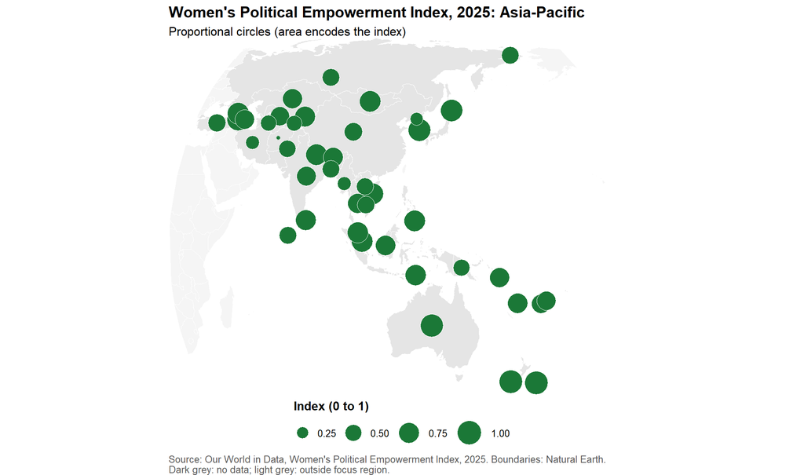

```r
prop_base_ap() +
  geom_point(data = pts_ap, aes(x = x, y = y, size = index),
             shape = 21, fill = sym_green, colour = "white", stroke = 0.3) +
  size_scale_ap + size_guide +
  prop_labs_ap + labs(subtitle = "Proportional circles (area encodes the index)") +
  map_theme
```

#### Map 9 — Proportional circles with transparency (Asia-Pacific)

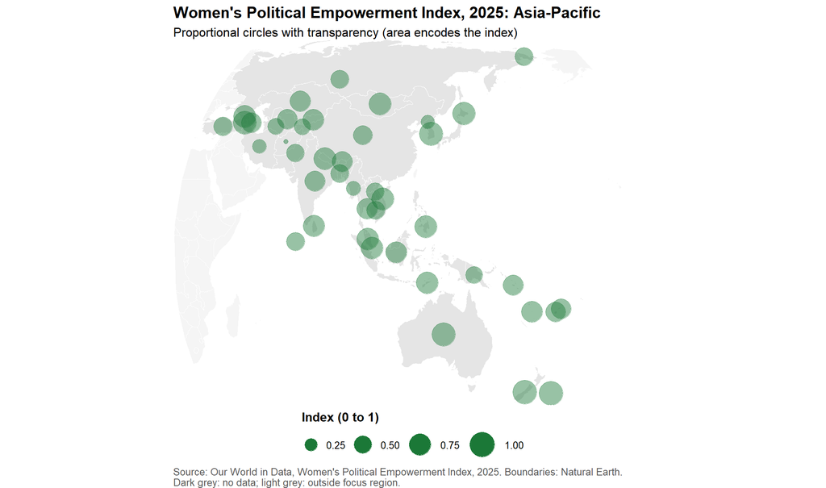

```r
prop_base_ap() +
  geom_point(data = pts_ap, aes(x = x, y = y, size = index),
             shape = 21, fill = sym_green, alpha = 0.45, colour = sym_green, stroke = 0.5) +
  size_scale_ap + size_guide +
  prop_labs_ap + labs(subtitle = "Proportional circles with transparency (area encodes the index)") +
  map_theme
```